# Problema 1 - Checkpoint 3 - Sua análise

## A avaliação de um episódio crossover é melhor que a avaliação média dos outros episódios das séries envolvidas?

Um crossover ficcional ocorre quando dois ou mais personagens de diferentes histórias e universos interagem. No mundo dos quadrinhos essa prática é bem comum, e as séries de tv baseadas em quadrinhos seguem a tradição. As séries Arrow, Flash e Legends of Tomorrow são situadas no universo compartilhado Arrowverse, e os crossovers são frequentes, permitindo a análise proposta nessa questão. Serão calculadas as avaliações médias para cada série, e depois comparadas com as avaliações de cada episódio crossover.

```r
dados = read_csv("C:/Users/gabim/Desktop/AD1/cdd-lab1-gabriela-motta/data/series_from_imdb.csv",
                    progress = FALSE,
                    col_types = cols(.default = col_double(),
                                     series_name = col_character(),
                                     episode = col_character(),
                                     url = col_character(),
                                     season = col_character())) %>% filter(series_name %in% c("Arrow", "Flash", "DCs Legends of Tomorrow"))
```

Primeiramente vamos calcular a avaliação média para cada série.

```r
sumarios = dados %>%
    group_by(series_name) %>%
    summarise(media = mean(user_rating))
sumarios
```

| series_name | media |
| --- | --- |
| Arrow | 8.549565 |
| DCs Legends of Tomorrow | 8.369697 |
| Flash | 8.702899 |

Vamos separar os episódios crossover, que para as séries Arrow e Flash sempre acontecem no 8º episódio da temporada, e para Legends of Tomorrow aconteceu no 7º episódio da segunda temporada. Como Arrow é a série mais antiga, os crossovers só começaram na sua terceira temporada. No total serão observados 7 episódios.

```r
crossovers_arrow = dados %>% filter(series_name %in% c("Arrow"), season == 3 | season == 4 | season == 5, season_ep == 8)
crossovers_arrow
```

| series_name | episode | series_ep | season | season_ep | url | user_rating | user_votes | r1 | r2 | r3 | r4 | r5 | r6 | r7 | r8 | r9 | r10 |
| --- | --- | --- | --- | --- | --- | --- | --- | --- | --- | --- | --- | --- | --- | --- | --- | --- | --- |
| Arrow | The Brave and the Bold | 54 | 3 | 8 | http://www.imdb.com/title/tt4006572/ | 9.3 | 4711 | 0.05104167 | 0.004513889 | 0.005555556 | 0.007986111 | 0.01701389 | 0.03055556 | 0.08055556 | 0.19236111 | 0.2166667 | 0.3937500 |
| Arrow | Legends of Yesterday | 77 | 4 | 8 | http://www.imdb.com/title/tt4859300/ | 9.1 | 3415 | 0.03981265 | 0.005269321 | 0.004098361 | 0.004976581 | 0.01258782 | 0.01727166 | 0.04537471 | 0.08957845 | 0.1800351 | 0.6009953 |
| Arrow | Invasion! | 100 | 5 | 8 | http://www.imdb.com/title/tt5584154/ | 9.3 | 3014 | 0.02717932 | 0.006960557 | 0.005966192 | 0.006297647 | 0.01160093 | 0.01325820 | 0.02353331 | 0.06397083 | 0.1564468 | 0.6847862 |

```r
crossovers_flash = dados %>% filter(series_name %in% c("Flash"), season_ep == 8)
crossovers_flash
```

| series_name | episode | series_ep | season | season_ep | url | user_rating | user_votes | r1 | r2 | r3 | r4 | r5 | r6 | r7 | r8 | r9 | r10 |
| --- | --- | --- | --- | --- | --- | --- | --- | --- | --- | --- | --- | --- | --- | --- | --- | --- | --- |
| Flash | Flash vs. Arrow | 8 | 1 | 8 | http://www.imdb.com/title/tt3922506/ | 9.4 | 6703 | 0.03505207 | 0.002540005 | 0.002032004 | 0.004318009 | 0.010414021 | 0.02616205 | 0.09474219 | 0.20320041 | 0.2453645 | 0.3761748 |
| Flash | Legends of Today | 31 | 2 | 8 | http://www.imdb.com/title/tt4857182/ | 9.2 | 4006 | 0.01747379 | 0.002246630 | 0.002745881 | 0.004992511 | 0.005242137 | 0.01797304 | 0.04418372 | 0.10783824 | 0.2054418 | 0.5918622 |
| Flash | Invasion! | 54 | 3 | 8 | http://www.imdb.com/title/tt5584134/ | 9.3 | 3117 | 0.02435117 | 0.005767382 | 0.003844921 | 0.005446972 | 0.008651073 | 0.01409805 | 0.02915732 | 0.07401474 | 0.1755847 | 0.6590836 |

```r
crossovers_legends = dados %>% filter(series_name %in% c("DCs Legends of Tomorrow"), season == 2, season_ep == 7)
crossovers_legends
```

| series_name | episode | series_ep | season | season_ep | url | user_rating | user_votes | r1 | r2 | r3 | r4 | r5 | r6 | r7 | r8 | r9 | r10 |
| --- | --- | --- | --- | --- | --- | --- | --- | --- | --- | --- | --- | --- | --- | --- | --- | --- | --- |
| DCs Legends of Tomorrow | Invasion! | 23 | 2 | 7 | http://www.imdb.com/title/tt5584108/ | 9.3 | 1938 | 0.01805986 | 0.004127967 | 0.004127967 | 0.005675955 | 0.01031992 | 0.01857585 | 0.03044376 | 0.0877193 | 0.1898865 | 0.631063 |

Agora podemos comparar as avaliações médias das séries com as avaliações dos 7 episódios crossover.

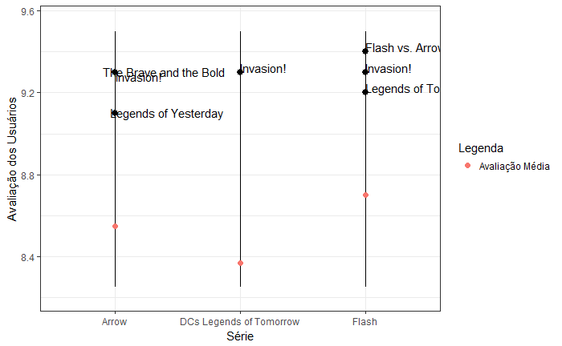

```r
plot1 <- ggplot(crossovers_arrow, aes(x = series_name, y = user_rating, ymin = 8.25, ymax = 9.5)) +
    geom_pointrange() +
    geom_pointrange(data = crossovers_flash) +
    geom_pointrange(data = crossovers_legends) +
    geom_point(data=sumarios, aes(x = sumarios$series_name, y = sumarios$media, color = "Avaliação Média"), size=2) +
    geom_text(aes(label=episode),hjust=0, vjust=-0.5,position=position_jitter(width=0.1,height=0.1)) +
    geom_text(data=crossovers_flash,aes(label=episode),hjust=0, vjust=0) +
    geom_text(data=crossovers_legends,aes(label=episode),hjust=0, vjust=0) +
    labs(x = "Série", y = "Avaliação dos Usuários", color="Legenda")
plot1
```

Podemos perceber que todos os episódios de crossover do Arrowverse apresentam avaliações bem acima das avaliações médias das séries, no intervalo de 9.1 a 9.4. Esses episódios geralmente são mais divulgados para atrair o público das outras séries, portanto podem obter mais votos. Também são episódios com mais ação, o que empolga o público.

### Os episódios crossover recebem mais votos que os episódios normais?

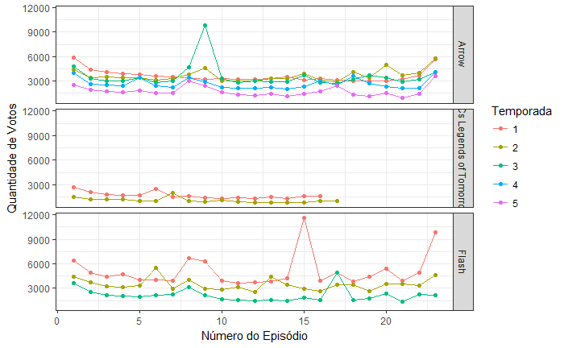

```r
dados %>%
  ggplot(aes(x = season_ep, y = user_votes, color = season)) +
  geom_line() +
  geom_point() +
  facet_grid(series_name ~ .) +
  labs(color ="Temporada", x = "Número do Episódio", y = "Quantidade de Votos")
```

É possível notar um aumento no número de votos nas proximidades do episódio 8, mas existem episódios com mais votos. Em Arrow o episódio seguinte ao crossover é o mais avaliado de toda a série, e em Flash existem vários picos, principalmente na primeira temporada. Legends of Tomorrow foi a única que apresentou mais votos em seu crossover, no episódio 7 da segunda temporada.

## Séries que possuem mais de 20 episódios por temporada possuem uma avaliação irregular?

Para essa questão serão avaliadas as séries Elementary, Lost e Os Feiticeiros de Waverly Place, que possuem no máximo 24, 25 e 30 episódios por temporada respectivamente.

```r
series = read_csv("C:/Users/gabim/Desktop/AD1/cdd-lab1-gabriela-motta/data/series_from_imdb.csv",
                    progress = FALSE,
                    col_types = cols(.default = col_double(),
                                     series_name = col_character(),
                                     episode = col_character(),
                                     url = col_character(),
                                     season = col_character())) %>% filter(series_name %in% c("Elementary", "Os Feiticeiros de Waverly Place", "Lost"))
```

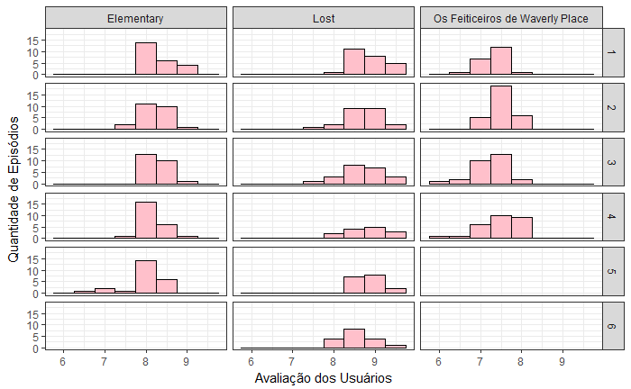

```r
series %>%
    ggplot(aes(x = user_rating)) +
    geom_histogram(binwidth = .5, fill = "pink", color = "black") +
    facet_grid(season ~ series_name) +
    labs(x = "Avaliação dos Usuários", y = "Quantidade de Episódios")
```

Com essa visualização podemos notar que Elementary possui avaliações bem regulares entre 8 e 8.5, exceto na quinta temporada, com notas variando entre 6.5 e 8.5. Lost possui as notas mais concentradas entre 8.5 e 9.0, porém possui algumas notas 7.0 e 9.5. Feiticeiros de Waverly Place possui uma grande irregularidade entre as temporadas 2 e 3. Na segunda temporada vemos uma grande quantidade de episódios com nota 7.5, mas na temporada seguinte os dados estão bem espalhados entre 6.0 e 8.0.

### A irregularidade de avaliações é percebida ao longo das temporadas ou em pontos específicos?

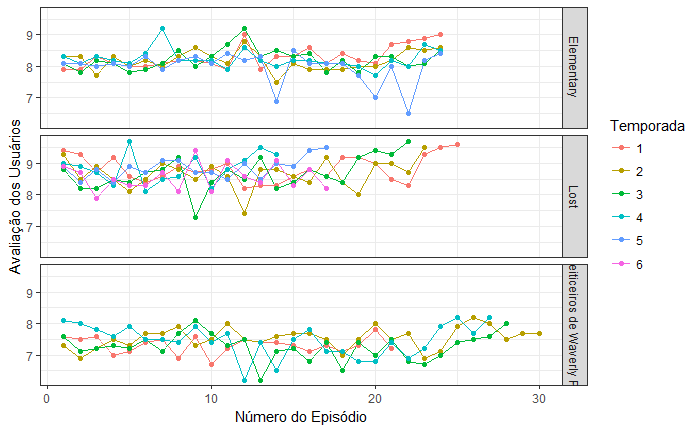

```r
series %>%
  ggplot(aes(x = season_ep, y = user_rating, color = season)) +
  geom_line() +
  geom_point() +
  facet_grid(series_name ~ .) +
  labs(color ="Temporada", x = "Número do Episódio", y = "Avaliação dos Usuários")
```

Avaliando os dados em um gráfico de linhas é fácil de perceber a irregularidade no final da quinta temporada de Elementary. Em Lost podemos ver uma grande oscilação nos episódios finais e do meio das temporadas 1, 2 e 3. A temporada 3 de Feiticeiros de Waverly Place é bem irregular, atingindo a pior nota aproximadamente na sua metade.